# mini Genome Wide Association Study (GWAS)

2022-11-06

## R Markdown

1. In Rstudio, make a new R markdown document. Write all comments and answers to questions outside of chunks and write all code inside of chunks.

```r
require(parathyroidSE)
data(parathyroidGenesSE)
parathyroidGenesSE
```

```
## class: RangedSummarizedExperiment
## dim: 63193 27
## metadata(1): MIAME
## assays(1): counts
## rownames(63193): ENSG00000000003 ENSG00000000005 ... LRG_98 LRG_99
## rowData names(0):
## colnames: NULL
## colData names(8): run experiment ... study sample
```

# load libraries

2. Install and load the parathyroidSE package. Take the last four digits of your student ID. With each digit corresponding to a sample, subset the dataset so that it only contains the samples that are in the last four digits of your student ID. Make a new column in the Sample table (colData()) called Comparison, and add to it the following values c(“a”,“a”,“b”,“b”). % https://www.dataquest.io/blog/add-column-to-dataframe-in-r/

Qiyuan: My last four digits are 5560. I replace the 0 with 9 since R indexing start from 1.

```r
colData(parathyroidGenesSE)
```

```
## DataFrame with 27 rows and 8 columns
##             run experiment  patient treatment     time submission     study
##     <character>   <factor> <factor>  <factor> <factor>   <factor>  <factor>
## 1     SRR479052  SRX140503        1   Control      24h  SRA051611 SRP012167
## 2     SRR479053  SRX140504        1   Control      48h  SRA051611 SRP012167
## 3     SRR479054  SRX140505        1   DPN          24h  SRA051611 SRP012167
## 4     SRR479055  SRX140506        1   DPN          48h  SRA051611 SRP012167
## 5     SRR479056  SRX140507        1   OHT          24h  SRA051611 SRP012167
## ...         ...        ...      ...       ...      ...        ...       ...
## 23    SRR479074  SRX140523        4       DPN      48h  SRA051611 SRP012167
## 24    SRR479075  SRX140523        4       DPN      48h  SRA051611 SRP012167
## 25    SRR479076  SRX140524        4       OHT      24h  SRA051611 SRP012167
## 26    SRR479077  SRX140525        4       OHT      48h  SRA051611 SRP012167
## 27    SRR479078  SRX140525        4       OHT      48h  SRA051611 SRP012167
##        sample
##      <factor>
## 1   SRS308865
## 2   SRS308866
## 3   SRS308867
## 4   SRS308868
## 5   SRS308869
## ...       ...
## 23  SRS308885
## 24  SRS308885
## 25  SRS308886
## 26  SRS308887
## 27  SRS308887
```

```r
data <- parathyroidGenesSE[,c(5,5,6,9)]  # row: genes, columns: samples
colData(data)$Comparison <-c("a", "a", "b", "b")
colData(data)
```

```
## DataFrame with 4 rows and 9 columns
##           run experiment  patient treatment     time submission     study
##   <character>   <factor> <factor>  <factor> <factor>   <factor>  <factor>
## 1   SRR479056  SRX140507        1       OHT      24h  SRA051611 SRP012167
## 2   SRR479056  SRX140507        1       OHT      24h  SRA051611 SRP012167
## 3   SRR479057  SRX140508        1       OHT      48h  SRA051611 SRP012167
## 4   SRR479060  SRX140511        2       DPN      24h  SRA051611 SRP012167
##      sample  Comparison
##    <factor> <character>
## 1 SRS308869           a
## 2 SRS308869           a
## 3 SRS308870           b
## 4 SRS308873           b
```

3. Get the dataset into a DESeqDataSet object and filter the dataset for lowly expressed genes.

```r
dds <- DESeqDataSet(data, design = ~Comparison)
# dds
nrow(dds)
```

```
## [1] 63193
```

```r
keep <- rowSums(counts(dds)) > 1
dds <- dds[keep,]
nrow(dds)
```

```
## [1] 21998
```

4. Perform a rlog transformation on the dataset and generate a heatmap of the top 100 expressed genes and Principal component plot, justify why or why not each sample likely represents the new Treatment column that you have added and if you should throw out any samples.

Qiyuan: If we find red and blue dots are together in the PCA plot, we might identify bad samples and we can throw them away.

```r
rld <- rlog(dds, blind=F) # blind=F has error
rld
```

```
## class: DESeqTransform
## dim: 21998 4
## metadata(2): MIAME version
## assays(1): ''
## rownames(21998): ENSG00000000003 ENSG00000000005 ... ENSG00000271670
##   ENSG00000271707
## rowData names(7): baseMean baseVar ... dispFit rlogIntercept
## colnames(4): 1 2 3 4
## colData names(10): run experiment ... Comparison sizeFactor
```

```r
topVarGenes <- head(order(-rowVars(assay(rld))), 100)
topVarGenes
```

```
##   [1] 16135  5175 18915 10781 12711  1558 11956  5906 13662 12484  4337  5161
##  [13]  7771  1280  5971   688  3370  3735 14202  1398  8759  1854 13057  7223
##  [25]   365  6030 11701  7805  2844  6350 11777  6027  7577  1468   305  8307
##  [37]  8631 18008  3965  4205 10718  2244  2394  7802 10740  5365  3909  7921
##  [49] 18790  3235  7065 13523 11769  7517 11014  9068 15233  5528 14172   401
##  [61]  1746  3079 10082  6981  5625  3967 11002  7724 15023 14581 15114 10051
##  [73]  5616 14158 11499  5884  7346  9391 13800  9384 11455 12800  9544   809
##  [85]  3246  4001 12752 10060  9806 12218  3976  9413 10211 13842  4226  5255
##  [97]   670  4362 11430  8137
```

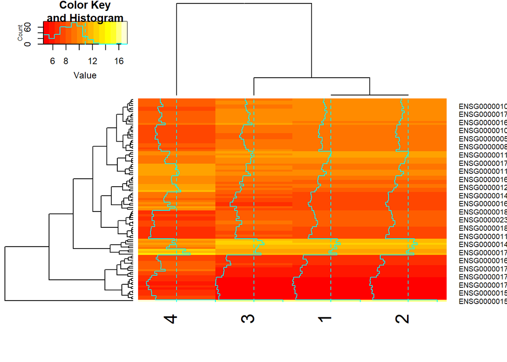

```r
heatmap.2(x=assay(rld)[topVarGenes,])
```

```r
# plotPCA(rld,intgroup=c("treatment", "Comparison"))

pcaData <- plotPCA(rld,intgroup=c("treatment","Comparison"),returnData=T)
pcaData
```

```
##         PC1        PC2 group treatment Comparison name
## 1 -6.020311 -2.0158045 OHT:a       OHT          a    1
## 2 -6.020311 -2.0158045 OHT:a       OHT          a    2
## 3 -4.657952  4.2887903 OHT:b       OHT          b    3
## 4 16.698575 -0.2571813 DPN:b       DPN          b    4
```

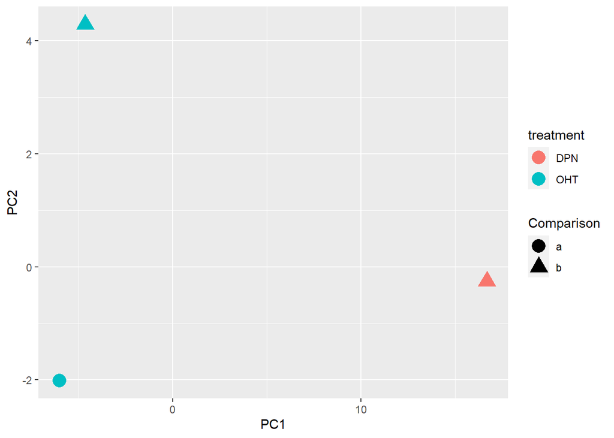

```r
ggplot(pcaData, aes(x=PC1,y=PC2, color=treatment, shape=Comparison)) +geom_point(size=5)
```

5. Generate a differential expression analysis looking for differentially expressed genes in the “b” treatment as compared to the “a” treatment. How many genes are differentially expressed with a LF C > 2 and an FDR adjusted p − value < 0.05? Show the top 10 most differentially expressed genes. Plot the results in a volcano plot using the enhancedVolcano package.

Qiyuan: 1 gene is differentially expressed. It’s ENSG00000184779.

```r
dds <- DESeq(dds)
res <- results(dds,contrast=c("Comparison", "a", "b"))
subres <- subset(res, log2FoldChange>2 & padj < 0.05)
subres
```

```
## log2 fold change (MLE): Comparison a vs b
## Wald test p-value: Comparison a vs b
## DataFrame with 1 row and 6 columns
##                  baseMean log2FoldChange     lfcSE      stat      pvalue
##                 <numeric>      <numeric> <numeric> <numeric>   <numeric>
## ENSG00000184779   214.158        2.48278  0.325922   7.61771 2.58215e-14
##                        padj
##                   <numeric>
## ENSG00000184779 2.37636e-10
```

Volcano plot:

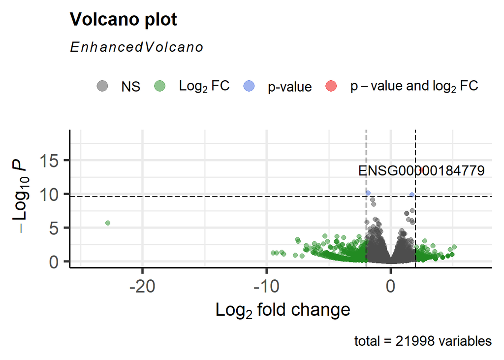

```r
EnhancedVolcano(res, lab=rownames(res), x='log2FoldChange',y='pvalue',pCutoff=subres$padj,FCcutoff = 2)
```

6. Using shinyGO: www.bioinformatics.sdstate.edu/go, determine if there is any GO pathways that are enriched among differentially expressed genes. If there are, import any table that shinyGO outputs into R studio and print it.

Qiyuan: Since there is only 1 significant gene, there is no pathways found.

7. If there are differentially expressed genes and enriched pathways, explain how the original treatment and factor conditions of the samples you compared could have effected this or if there aren’t, justify why there are no differentially expressed genes.

Qiyuan: there are only 1 differentially expressed gene but not enriched pathways.

8. Finally, compile the markdown document into a PDF document and upload it to Canvas. Submit both this file and a file containing the code.

# Difficulty adjustment

How long did this assignment take you to complete?

If the assignment took you longer than the 10 hours, which parts were overly difficult?